# Risk Factor Analysis

## Outcome Variable

**Outcome Variable:** haz

## Predictor Variables

**Intervention Variable:** predexfd6

**Adjustment Set:**

- arm
- sex
- brthmon
- W_mage
- meducyrs
- feducyrs
- hhwealth_quart
- hfoodsec
- W_mhtcm
- W_mwtkg
- W_mbmi
- vagbrth
- W_gagebrth
- W_birthwt
- W_birthlen
- W_nrooms
- W_nchldlt5
- month
- W_parity
- impfloor
- impsan
- safeh20
- delta_W_mage
- delta_meducyrs
- delta_feducyrs
- delta_hhwealth_quart
- delta_hfoodsec
- delta_W_mhtcm
- delta_W_mwtkg
- delta_W_mbmi
- delta_vagbrth
- delta_W_gagebrth
- delta_W_birthwt
- delta_W_birthlen
- delta_W_nrooms
- delta_W_nchldlt5
- delta_month
- delta_W_parity
- delta_impfloor
- delta_impsan
- delta_safeh20

## Stratifying Variables

The analysis was stratified on these variable(s):

- agecat
- studyid
- country

## Data Summary

| agecat | studyid | country | predexfd6 | n_cell | n | outcome_variable |
| --- | --- | --- | --- | --- | --- | --- |
| Birth | CMC-V-BCS-2002 | INDIA | 1 | 7 | 7 | haz |
| Birth | CMC-V-BCS-2002 | INDIA | 0 | 0 | 7 | haz |
| Birth | EE | PAKISTAN | 1 | 38 | 42 | haz |
| Birth | EE | PAKISTAN | 0 | 4 | 42 | haz |
| Birth | GMS-Nepal | NEPAL | 1 | 419 | 563 | haz |
| Birth | GMS-Nepal | NEPAL | 0 | 144 | 563 | haz |
| Birth | IRC | INDIA | 1 | 0 | 14 | haz |
| Birth | IRC | INDIA | 0 | 14 | 14 | haz |
| Birth | JiVitA-3 | BANGLADESH | 1 | 10466 | 13423 | haz |
| Birth | JiVitA-3 | BANGLADESH | 0 | 2957 | 13423 | haz |
| Birth | JiVitA-4 | BANGLADESH | 1 | 2103 | 2632 | haz |
| Birth | JiVitA-4 | BANGLADESH | 0 | 529 | 2632 | haz |
| Birth | Keneba | GAMBIA | 1 | 485 | 1403 | haz |
| Birth | Keneba | GAMBIA | 0 | 918 | 1403 | haz |
| Birth | MAL-ED | BANGLADESH | 1 | 72 | 205 | haz |
| Birth | MAL-ED | BANGLADESH | 0 | 133 | 205 | haz |
| Birth | MAL-ED | BRAZIL | 1 | 6 | 60 | haz |
| Birth | MAL-ED | BRAZIL | 0 | 54 | 60 | haz |
| Birth | MAL-ED | INDIA | 1 | 4 | 39 | haz |
| Birth | MAL-ED | INDIA | 0 | 35 | 39 | haz |
| Birth | MAL-ED | NEPAL | 1 | 3 | 24 | haz |
| Birth | MAL-ED | NEPAL | 0 | 21 | 24 | haz |
| Birth | MAL-ED | PERU | 1 | 73 | 213 | haz |
| Birth | MAL-ED | PERU | 0 | 140 | 213 | haz |
| Birth | MAL-ED | SOUTH AFRICA | 1 | 1 | 91 | haz |
| Birth | MAL-ED | SOUTH AFRICA | 0 | 90 | 91 | haz |
| Birth | MAL-ED | TANZANIA, UNITED REPUBLIC OF | 1 | 0 | 113 | haz |
| Birth | MAL-ED | TANZANIA, UNITED REPUBLIC OF | 0 | 113 | 113 | haz |
| Birth | PROVIDE | BANGLADESH | 1 | 159 | 539 | haz |
| Birth | PROVIDE | BANGLADESH | 0 | 380 | 539 | haz |

[output cut: 70 more lines]

The following strata were considered:

- agecat: 24 months, studyid: CMC-V-BCS-2002, country: INDIA
- agecat: 24 months, studyid: EE, country: PAKISTAN
- agecat: 24 months, studyid: GMS-Nepal, country: NEPAL
- agecat: 24 months, studyid: IRC, country: INDIA
- agecat: 24 months, studyid: JiVitA-3, country: BANGLADESH
- agecat: 24 months, studyid: JiVitA-4, country: BANGLADESH
- agecat: 24 months, studyid: Keneba, country: GAMBIA
- agecat: 24 months, studyid: LCNI-5, country: MALAWI
- agecat: 24 months, studyid: MAL-ED, country: BANGLADESH
- agecat: 24 months, studyid: MAL-ED, country: BRAZIL
- agecat: 24 months, studyid: MAL-ED, country: INDIA
- agecat: 24 months, studyid: MAL-ED, country: NEPAL
- agecat: 24 months, studyid: MAL-ED, country: PERU
- agecat: 24 months, studyid: MAL-ED, country: SOUTH AFRICA
- agecat: 24 months, studyid: MAL-ED, country: TANZANIA, UNITED REPUBLIC OF
- agecat: 24 months, studyid: PROVIDE, country: BANGLADESH
- agecat: 6 months, studyid: CMC-V-BCS-2002, country: INDIA
- agecat: 6 months, studyid: EE, country: PAKISTAN
- agecat: 6 months, studyid: GMS-Nepal, country: NEPAL
- agecat: 6 months, studyid: IRC, country: INDIA
- agecat: 6 months, studyid: JiVitA-3, country: BANGLADESH
- agecat: 6 months, studyid: JiVitA-4, country: BANGLADESH
- agecat: 6 months, studyid: Keneba, country: GAMBIA
- agecat: 6 months, studyid: LCNI-5, country: MALAWI
- agecat: 6 months, studyid: MAL-ED, country: BANGLADESH
- agecat: 6 months, studyid: MAL-ED, country: BRAZIL
- agecat: 6 months, studyid: MAL-ED, country: INDIA
- agecat: 6 months, studyid: MAL-ED, country: NEPAL
- agecat: 6 months, studyid: MAL-ED, country: PERU
- agecat: 6 months, studyid: MAL-ED, country: SOUTH AFRICA
- agecat: 6 months, studyid: MAL-ED, country: TANZANIA, UNITED REPUBLIC OF
- agecat: 6 months, studyid: PROVIDE, country: BANGLADESH
- agecat: 6 months, studyid: SAS-CompFeed, country: INDIA
- agecat: 6 months, studyid: SAS-FoodSuppl, country: INDIA
- agecat: Birth, studyid: CMC-V-BCS-2002, country: INDIA
- agecat: Birth, studyid: EE, country: PAKISTAN
- agecat: Birth, studyid: GMS-Nepal, country: NEPAL
- agecat: Birth, studyid: IRC, country: INDIA
- agecat: Birth, studyid: JiVitA-3, country: BANGLADESH
- agecat: Birth, studyid: JiVitA-4, country: BANGLADESH
- agecat: Birth, studyid: Keneba, country: GAMBIA
- agecat: Birth, studyid: MAL-ED, country: BANGLADESH
- agecat: Birth, studyid: MAL-ED, country: BRAZIL
- agecat: Birth, studyid: MAL-ED, country: INDIA
- agecat: Birth, studyid: MAL-ED, country: NEPAL
- agecat: Birth, studyid: MAL-ED, country: PERU
- agecat: Birth, studyid: MAL-ED, country: SOUTH AFRICA
- agecat: Birth, studyid: MAL-ED, country: TANZANIA, UNITED REPUBLIC OF
- agecat: Birth, studyid: PROVIDE, country: BANGLADESH
- agecat: Birth, studyid: SAS-CompFeed, country: INDIA

### Dropped Strata

Some strata were dropped due to rare outcomes:

- agecat: Birth, studyid: CMC-V-BCS-2002, country: INDIA
- agecat: Birth, studyid: EE, country: PAKISTAN
- agecat: Birth, studyid: IRC, country: INDIA
- agecat: Birth, studyid: MAL-ED, country: INDIA
- agecat: Birth, studyid: MAL-ED, country: NEPAL
- agecat: Birth, studyid: MAL-ED, country: SOUTH AFRICA
- agecat: Birth, studyid: MAL-ED, country: TANZANIA, UNITED REPUBLIC OF
- agecat: 6 months, studyid: CMC-V-BCS-2002, country: INDIA
- agecat: 6 months, studyid: IRC, country: INDIA
- agecat: 6 months, studyid: MAL-ED, country: SOUTH AFRICA
- agecat: 6 months, studyid: MAL-ED, country: TANZANIA, UNITED REPUBLIC OF
- agecat: 6 months, studyid: SAS-FoodSuppl, country: INDIA
- agecat: 24 months, studyid: CMC-V-BCS-2002, country: INDIA
- agecat: 24 months, studyid: EE, country: PAKISTAN
- agecat: 24 months, studyid: IRC, country: INDIA
- agecat: 24 months, studyid: MAL-ED, country: SOUTH AFRICA
- agecat: 24 months, studyid: MAL-ED, country: TANZANIA, UNITED REPUBLIC OF

## Methods Detail

We’re interested in the causal parameters $E[Y_a]$ for all values of $a \in \mathcal{A}$. These parameters represent the mean outcome if, possibly contrary to fact, we intervened to set all units to have $A=a$. Under the randomization and positivity assumptions, these are identified by the statistical parameters $\psi_a=E_W[E_{Y|A,W}(Y|A=a,W)]$. In addition, we’re interested in the mean of $Y$, $E[Y]$ under no intervention (the observed mean). We will estimate these parameters by using SuperLearner to fit the relevant likelihood factors – $E_{Y|A,W}(Y|A=a,W)$ and $p(A=a|W)$, and then updating our likelihood fit using a joint TMLE.

For unadjusted analyses ($W=\{\}$), initial likelihoods were estimated using Lrnr_glm to estimate the simple $E(Y|A)$ and Lrnr_mean to estimate $p(A)$. For adjusted analyses, a small library containing Lrnr_glmnet, Lrnr_xgboost, and Lrnr_mean was used.

Having estimated these parameters, we will then use the delta method to estimate relative risks and attributable risks relative to a prespecified baseline level of $A$.

# Results Detail

## Results Plots

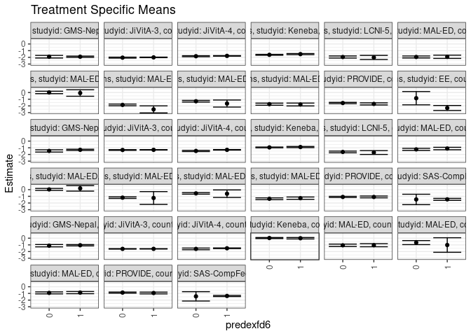

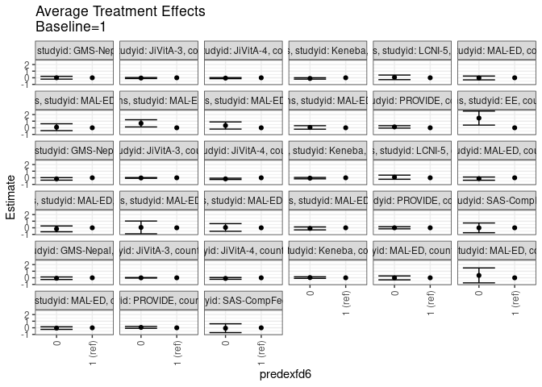

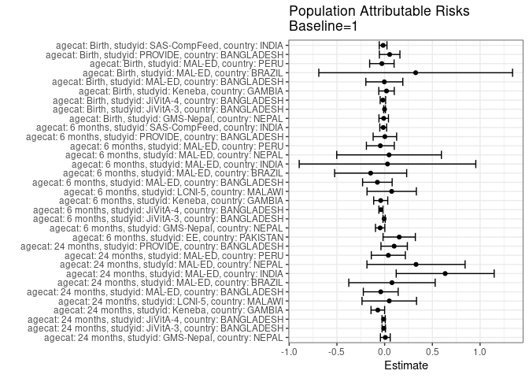

## Results Table

### Parameter: TSM

| agecat | studyid | country | intervention_level | baseline_level | estimate | ci_lower | ci_upper |
| --- | --- | --- | --- | --- | --- | --- | --- |
| Birth | GMS-Nepal | NEPAL | 1 | NA | -1.0544641 | -1.1518255 | -0.9571027 |
| Birth | GMS-Nepal | NEPAL | 0 | NA | -1.1202663 | -1.2965789 | -0.9439537 |
| Birth | JiVitA-3 | BANGLADESH | 1 | NA | -1.5946890 | -1.6194672 | -1.5699108 |
| Birth | JiVitA-3 | BANGLADESH | 0 | NA | -1.5980065 | -1.6373136 | -1.5586994 |
| Birth | JiVitA-4 | BANGLADESH | 1 | NA | -1.5091167 | -1.5613777 | -1.4568557 |
| Birth | JiVitA-4 | BANGLADESH | 0 | NA | -1.6022009 | -1.7298527 | -1.4745492 |
| Birth | Keneba | GAMBIA | 1 | NA | -0.0072101 | -0.1150396 | 0.1006194 |
| Birth | Keneba | GAMBIA | 0 | NA | 0.0247498 | -0.0542056 | 0.1037053 |
| Birth | MAL-ED | BANGLADESH | 1 | NA | -1.0498479 | -1.2794300 | -0.8202658 |
| Birth | MAL-ED | BANGLADESH | 0 | NA | -1.0626195 | -1.2417289 | -0.8835102 |
| Birth | MAL-ED | BRAZIL | 1 | NA | -1.0216667 | -2.1085384 | 0.0652051 |
| Birth | MAL-ED | BRAZIL | 0 | NA | -0.6601852 | -0.9595686 | -0.3608018 |
| Birth | MAL-ED | PERU | 1 | NA | -0.8776044 | -1.0427338 | -0.7124749 |
| Birth | MAL-ED | PERU | 0 | NA | -0.9207338 | -1.0691906 | -0.7722771 |
| Birth | PROVIDE | BANGLADESH | 1 | NA | -0.9376219 | -1.0673724 | -0.8078714 |
| Birth | PROVIDE | BANGLADESH | 0 | NA | -0.8749844 | -0.9618567 | -0.7881121 |
| Birth | SAS-CompFeed | INDIA | 1 | NA | -1.3776197 | -1.4631704 | -1.2920690 |
| Birth | SAS-CompFeed | INDIA | 0 | NA | -1.4364436 | -2.1366347 | -0.7362525 |
| 6 months | EE | PAKISTAN | 1 | NA | -2.3121318 | -2.6865239 | -1.9377397 |
| 6 months | EE | PAKISTAN | 0 | NA | -0.8473333 | -1.8424880 | 0.1478213 |
| 6 months | GMS-Nepal | NEPAL | 1 | NA | -1.3070013 | -1.3958834 | -1.2181191 |
| 6 months | GMS-Nepal | NEPAL | 0 | NA | -1.4720513 | -1.6419461 | -1.3021565 |
| 6 months | JiVitA-3 | BANGLADESH | 1 | NA | -1.3085486 | -1.3389818 | -1.2781153 |
| 6 months | JiVitA-3 | BANGLADESH | 0 | NA | -1.3326171 | -1.3819007 | -1.2833334 |
| 6 months | JiVitA-4 | BANGLADESH | 1 | NA | -1.3095165 | -1.3504487 | -1.2685843 |
| 6 months | JiVitA-4 | BANGLADESH | 0 | NA | -1.4729347 | -1.5631742 | -1.3826952 |
| 6 months | Keneba | GAMBIA | 1 | NA | -0.8920431 | -0.9808636 | -0.8032226 |
| 6 months | Keneba | GAMBIA | 0 | NA | -0.9469047 | -1.0056703 | -0.8881390 |
| 6 months | LCNI-5 | MALAWI | 1 | NA | -1.7134805 | -1.9994541 | -1.4275068 |
| 6 months | LCNI-5 | MALAWI | 0 | NA | -1.6256196 | -1.7565828 | -1.4946564 |
| 6 months | MAL-ED | BANGLADESH | 1 | NA | -1.1140250 | -1.2969354 | -0.9311146 |
| 6 months | MAL-ED | BANGLADESH | 0 | NA | -1.2408264 | -1.3956843 | -1.0859684 |
| 6 months | MAL-ED | BRAZIL | 1 | NA | 0.1941036 | -0.2177991 | 0.6060063 |
| 6 months | MAL-ED | BRAZIL | 0 | NA | 0.0312538 | -0.1185736 | 0.1810812 |
| 6 months | MAL-ED | INDIA | 1 | NA | -1.2488776 | -2.2079269 | -0.2898282 |
| 6 months | MAL-ED | INDIA | 0 | NA | -1.1939063 | -1.3147647 | -1.0730478 |
| 6 months | MAL-ED | NEPAL | 1 | NA | -0.6086820 | -1.1726910 | -0.0446729 |
| 6 months | MAL-ED | NEPAL | 0 | NA | -0.5572679 | -0.6755468 | -0.4389889 |
| 6 months | MAL-ED | PERU | 1 | NA | -1.2771506 | -1.4523624 | -1.1019389 |
| 6 months | MAL-ED | PERU | 0 | NA | -1.3691056 | -1.5057296 | -1.2324816 |
| 6 months | PROVIDE | BANGLADESH | 1 | NA | -1.0943573 | -1.2293089 | -0.9594057 |
| 6 months | PROVIDE | BANGLADESH | 0 | NA | -1.0930770 | -1.1807358 | -1.0054181 |
| 6 months | SAS-CompFeed | INDIA | 1 | NA | -1.4549959 | -1.6008850 | -1.3091069 |
| 6 months | SAS-CompFeed | INDIA | 0 | NA | -1.4654856 | -2.2428805 | -0.6880907 |
| 24 months | GMS-Nepal | NEPAL | 1 | NA | -1.9073912 | -2.0023116 | -1.8124709 |
| 24 months | GMS-Nepal | NEPAL | 0 | NA | -1.9045786 | -2.0989385 | -1.7102187 |
| 24 months | JiVitA-3 | BANGLADESH | 1 | NA | -2.0026992 | -2.0426011 | -1.9627973 |
| 24 months | JiVitA-3 | BANGLADESH | 0 | NA | -2.0415106 | -2.1116982 | -1.9713230 |
| 24 months | JiVitA-4 | BANGLADESH | 1 | NA | -1.7810986 | -1.8228610 | -1.7393361 |
| 24 months | JiVitA-4 | BANGLADESH | 0 | NA | -1.8329213 | -1.9086002 | -1.7572423 |
| 24 months | Keneba | GAMBIA | 1 | NA | -1.5162493 | -1.6015608 | -1.4309378 |
| 24 months | Keneba | GAMBIA | 0 | NA | -1.6194716 | -1.6859486 | -1.5529946 |
| 24 months | LCNI-5 | MALAWI | 1 | NA | -2.0137333 | -2.3203902 | -1.7070764 |
| 24 months | LCNI-5 | MALAWI | 0 | NA | -1.9495008 | -2.1077066 | -1.7912950 |
| 24 months | MAL-ED | BANGLADESH | 1 | NA | -1.9169230 | -2.1574062 | -1.6764397 |
| 24 months | MAL-ED | BANGLADESH | 0 | NA | -1.9433159 | -2.0903643 | -1.7962676 |
| 24 months | MAL-ED | BRAZIL | 1 | NA | -0.0708919 | -0.5566598 | 0.4148760 |
| 24 months | MAL-ED | BRAZIL | 0 | NA | 0.0160534 | -0.1680078 | 0.2001145 |
| 24 months | MAL-ED | INDIA | 1 | NA | -2.5207714 | -3.0470193 | -1.9945236 |
| 24 months | MAL-ED | INDIA | 0 | NA | -1.8513087 | -1.9826807 | -1.7199366 |
| 24 months | MAL-ED | NEPAL | 1 | NA | -1.6475469 | -2.1748182 | -1.1202755 |
| 24 months | MAL-ED | NEPAL | 0 | NA | -1.3058504 | -1.4313726 | -1.1803283 |
| 24 months | MAL-ED | PERU | 1 | NA | -1.7912200 | -2.0049547 | -1.5774854 |
| 24 months | MAL-ED | PERU | 0 | NA | -1.7408866 | -1.8948454 | -1.5869278 |
| 24 months | PROVIDE | BANGLADESH | 1 | NA | -1.7020404 | -1.8590794 | -1.5450014 |
| 24 months | PROVIDE | BANGLADESH | 0 | NA | -1.5696558 | -1.6654226 | -1.4738890 |

### Parameter: E(Y)

| agecat | studyid | country | intervention_level | baseline_level | estimate | ci_lower | ci_upper |
| --- | --- | --- | --- | --- | --- | --- | --- |
| Birth | GMS-Nepal | NEPAL | NA | NA | -1.0641208 | -1.1525364 | -0.9757052 |
| Birth | JiVitA-3 | BANGLADESH | NA | NA | -1.5955338 | -1.6186322 | -1.5724354 |
| Birth | JiVitA-4 | BANGLADESH | NA | NA | -1.5273138 | -1.5765339 | -1.4780937 |
| Birth | Keneba | GAMBIA | NA | NA | 0.0126443 | -0.0554367 | 0.0807254 |
| Birth | MAL-ED | BANGLADESH | NA | NA | -1.0530244 | -1.1913751 | -0.9146736 |
| Birth | MAL-ED | BRAZIL | NA | NA | -0.6963333 | -0.9881882 | -0.4044785 |
| Birth | MAL-ED | PERU | NA | NA | -0.9065728 | -1.0297267 | -0.7834188 |
| Birth | PROVIDE | BANGLADESH | NA | NA | -0.8851020 | -0.9601332 | -0.8100709 |
| Birth | SAS-CompFeed | INDIA | NA | NA | -1.3937088 | -1.5095039 | -1.2779137 |
| 6 months | EE | PAKISTAN | NA | NA | -2.1595486 | -2.5331781 | -1.7859192 |
| 6 months | GMS-Nepal | NEPAL | NA | NA | -1.3540280 | -1.4334801 | -1.2745760 |
| 6 months | JiVitA-3 | BANGLADESH | NA | NA | -1.3138259 | -1.3418712 | -1.2857806 |
| 6 months | JiVitA-4 | BANGLADESH | NA | NA | -1.3482303 | -1.3866421 | -1.3098185 |
| 6 months | Keneba | GAMBIA | NA | NA | -0.9331108 | -0.9823173 | -0.8839043 |
| 6 months | LCNI-5 | MALAWI | NA | NA | -1.6395956 | -1.7592633 | -1.5199278 |
| 6 months | MAL-ED | BANGLADESH | NA | NA | -1.1900794 | -1.3096296 | -1.0705291 |
| 6 months | MAL-ED | BRAZIL | NA | NA | 0.0475758 | -0.0963508 | 0.1915023 |
| 6 months | MAL-ED | INDIA | NA | NA | -1.2188303 | -1.3423090 | -1.0953516 |
| 6 months | MAL-ED | NEPAL | NA | NA | -0.5622370 | -0.6774081 | -0.4470660 |
| 6 months | MAL-ED | PERU | NA | NA | -1.3220326 | -1.4308168 | -1.2132484 |
| 6 months | PROVIDE | BANGLADESH | NA | NA | -1.0916915 | -1.1661176 | -1.0172654 |
| 6 months | SAS-CompFeed | INDIA | NA | NA | -1.4697236 | -1.6333919 | -1.3060553 |
| 24 months | GMS-Nepal | NEPAL | NA | NA | -1.9002128 | -1.9869255 | -1.8135001 |
| 24 months | JiVitA-3 | BANGLADESH | NA | NA | -2.0118003 | -2.0479952 | -1.9756055 |
| 24 months | JiVitA-4 | BANGLADESH | NA | NA | -1.7914765 | -1.8297816 | -1.7531715 |
| 24 months | Keneba | GAMBIA | NA | NA | -1.5876293 | -1.6406755 | -1.5345831 |
| 24 months | LCNI-5 | MALAWI | NA | NA | -1.9651323 | -2.1053230 | -1.8249415 |
| 24 months | MAL-ED | BANGLADESH | NA | NA | -1.9576341 | -2.0857597 | -1.8295086 |
| 24 months | MAL-ED | BRAZIL | NA | NA | 0.0061144 | -0.1625850 | 0.1748138 |
| 24 months | MAL-ED | INDIA | NA | NA | -1.8863397 | -2.0168508 | -1.7558287 |
| 24 months | MAL-ED | NEPAL | NA | NA | -1.3187671 | -1.4406685 | -1.1968657 |
| 24 months | MAL-ED | PERU | NA | NA | -1.7524710 | -1.8736426 | -1.6312994 |
| 24 months | PROVIDE | BANGLADESH | NA | NA | -1.6024221 | -1.6857420 | -1.5191023 |

### Parameter: ATE

| agecat | studyid | country | intervention_level | baseline_level | estimate | ci_lower | ci_upper |
| --- | --- | --- | --- | --- | --- | --- | --- |
| Birth | GMS-Nepal | NEPAL | 1 | 1 | 0.0000000 | 0.0000000 | 0.0000000 |
| Birth | GMS-Nepal | NEPAL | 0 | 1 | -0.0658022 | -0.2601184 | 0.1285140 |
| Birth | JiVitA-3 | BANGLADESH | 1 | 1 | 0.0000000 | 0.0000000 | 0.0000000 |
| Birth | JiVitA-3 | BANGLADESH | 0 | 1 | -0.0033175 | -0.0440879 | 0.0374529 |
| Birth | JiVitA-4 | BANGLADESH | 1 | 1 | 0.0000000 | 0.0000000 | 0.0000000 |
| Birth | JiVitA-4 | BANGLADESH | 0 | 1 | -0.0930843 | -0.2301065 | 0.0439379 |
| Birth | Keneba | GAMBIA | 1 | 1 | 0.0000000 | 0.0000000 | 0.0000000 |
| Birth | Keneba | GAMBIA | 0 | 1 | 0.0319599 | -0.0917417 | 0.1556616 |
| Birth | MAL-ED | BANGLADESH | 1 | 1 | 0.0000000 | 0.0000000 | 0.0000000 |
| Birth | MAL-ED | BANGLADESH | 0 | 1 | -0.0127716 | -0.3048193 | 0.2792760 |
| Birth | MAL-ED | BRAZIL | 1 | 1 | 0.0000000 | 0.0000000 | 0.0000000 |
| Birth | MAL-ED | BRAZIL | 0 | 1 | 0.3614815 | -0.7658697 | 1.4888326 |
| Birth | MAL-ED | PERU | 1 | 1 | 0.0000000 | 0.0000000 | 0.0000000 |
| Birth | MAL-ED | PERU | 0 | 1 | -0.0431295 | -0.2380806 | 0.1518217 |
| Birth | PROVIDE | BANGLADESH | 1 | 1 | 0.0000000 | 0.0000000 | 0.0000000 |
| Birth | PROVIDE | BANGLADESH | 0 | 1 | 0.0626376 | -0.0812106 | 0.2064858 |
| Birth | SAS-CompFeed | INDIA | 1 | 1 | 0.0000000 | 0.0000000 | 0.0000000 |
| Birth | SAS-CompFeed | INDIA | 0 | 1 | -0.0588239 | -0.7253365 | 0.6076887 |
| 6 months | EE | PAKISTAN | 1 | 1 | 0.0000000 | 0.0000000 | 0.0000000 |
| 6 months | EE | PAKISTAN | 0 | 1 | 1.4647984 | 0.4015477 | 2.5280492 |
| 6 months | GMS-Nepal | NEPAL | 1 | 1 | 0.0000000 | 0.0000000 | 0.0000000 |
| 6 months | GMS-Nepal | NEPAL | 0 | 1 | -0.1650501 | -0.3559386 | 0.0258384 |
| 6 months | JiVitA-3 | BANGLADESH | 1 | 1 | 0.0000000 | 0.0000000 | 0.0000000 |
| 6 months | JiVitA-3 | BANGLADESH | 0 | 1 | -0.0240685 | -0.0764339 | 0.0282969 |
| 6 months | JiVitA-4 | BANGLADESH | 1 | 1 | 0.0000000 | 0.0000000 | 0.0000000 |
| 6 months | JiVitA-4 | BANGLADESH | 0 | 1 | -0.1634183 | -0.2610280 | -0.0658085 |
| 6 months | Keneba | GAMBIA | 1 | 1 | 0.0000000 | 0.0000000 | 0.0000000 |
| 6 months | Keneba | GAMBIA | 0 | 1 | -0.0548616 | -0.1601937 | 0.0504705 |
| 6 months | LCNI-5 | MALAWI | 1 | 1 | 0.0000000 | 0.0000000 | 0.0000000 |
| 6 months | LCNI-5 | MALAWI | 0 | 1 | 0.0878609 | -0.2232350 | 0.3989567 |
| 6 months | MAL-ED | BANGLADESH | 1 | 1 | 0.0000000 | 0.0000000 | 0.0000000 |
| 6 months | MAL-ED | BANGLADESH | 0 | 1 | -0.1268014 | -0.3682278 | 0.1146251 |
| 6 months | MAL-ED | BRAZIL | 1 | 1 | 0.0000000 | 0.0000000 | 0.0000000 |
| 6 months | MAL-ED | BRAZIL | 0 | 1 | -0.1628498 | -0.6029261 | 0.2772264 |
| 6 months | MAL-ED | INDIA | 1 | 1 | 0.0000000 | 0.0000000 | 0.0000000 |
| 6 months | MAL-ED | INDIA | 0 | 1 | 0.0549713 | -0.9111237 | 1.0210662 |
| 6 months | MAL-ED | NEPAL | 1 | 1 | 0.0000000 | 0.0000000 | 0.0000000 |
| 6 months | MAL-ED | NEPAL | 0 | 1 | 0.0514141 | -0.5247832 | 0.6276115 |
| 6 months | MAL-ED | PERU | 1 | 1 | 0.0000000 | 0.0000000 | 0.0000000 |
| 6 months | MAL-ED | PERU | 0 | 1 | -0.0919550 | -0.3126935 | 0.1287836 |
| 6 months | PROVIDE | BANGLADESH | 1 | 1 | 0.0000000 | 0.0000000 | 0.0000000 |
| 6 months | PROVIDE | BANGLADESH | 0 | 1 | 0.0012803 | -0.1588329 | 0.1613936 |
| 6 months | SAS-CompFeed | INDIA | 1 | 1 | 0.0000000 | 0.0000000 | 0.0000000 |
| 6 months | SAS-CompFeed | INDIA | 0 | 1 | -0.0104897 | -0.7471588 | 0.7261794 |
| 24 months | GMS-Nepal | NEPAL | 1 | 1 | 0.0000000 | 0.0000000 | 0.0000000 |
| 24 months | GMS-Nepal | NEPAL | 0 | 1 | 0.0028126 | -0.2112306 | 0.2168559 |
| 24 months | JiVitA-3 | BANGLADESH | 1 | 1 | 0.0000000 | 0.0000000 | 0.0000000 |
| 24 months | JiVitA-3 | BANGLADESH | 0 | 1 | -0.0388114 | -0.1157572 | 0.0381345 |
| 24 months | JiVitA-4 | BANGLADESH | 1 | 1 | 0.0000000 | 0.0000000 | 0.0000000 |
| 24 months | JiVitA-4 | BANGLADESH | 0 | 1 | -0.0518227 | -0.1328240 | 0.0291786 |
| 24 months | Keneba | GAMBIA | 1 | 1 | 0.0000000 | 0.0000000 | 0.0000000 |
| 24 months | Keneba | GAMBIA | 0 | 1 | -0.1032223 | -0.2106039 | 0.0041593 |
| 24 months | LCNI-5 | MALAWI | 1 | 1 | 0.0000000 | 0.0000000 | 0.0000000 |
| 24 months | LCNI-5 | MALAWI | 0 | 1 | 0.0642325 | -0.2812914 | 0.4097563 |
| 24 months | MAL-ED | BANGLADESH | 1 | 1 | 0.0000000 | 0.0000000 | 0.0000000 |
| 24 months | MAL-ED | BANGLADESH | 0 | 1 | -0.0263930 | -0.3122609 | 0.2594750 |
| 24 months | MAL-ED | BRAZIL | 1 | 1 | 0.0000000 | 0.0000000 | 0.0000000 |
| 24 months | MAL-ED | BRAZIL | 0 | 1 | 0.0869453 | -0.4335266 | 0.6074172 |
| 24 months | MAL-ED | INDIA | 1 | 1 | 0.0000000 | 0.0000000 | 0.0000000 |
| 24 months | MAL-ED | INDIA | 0 | 1 | 0.6694628 | 0.1269639 | 1.2119616 |
| 24 months | MAL-ED | NEPAL | 1 | 1 | 0.0000000 | 0.0000000 | 0.0000000 |
| 24 months | MAL-ED | NEPAL | 0 | 1 | 0.3416964 | -0.1998026 | 0.8831955 |
| 24 months | MAL-ED | PERU | 1 | 1 | 0.0000000 | 0.0000000 | 0.0000000 |
| 24 months | MAL-ED | PERU | 0 | 1 | 0.0503334 | -0.2136712 | 0.3143381 |
| 24 months | PROVIDE | BANGLADESH | 1 | 1 | 0.0000000 | 0.0000000 | 0.0000000 |
| 24 months | PROVIDE | BANGLADESH | 0 | 1 | 0.1323846 | -0.0484723 | 0.3132416 |

### Parameter: PAR

| agecat | studyid | country | intervention_level | baseline_level | estimate | ci_lower | ci_upper |
| --- | --- | --- | --- | --- | --- | --- | --- |
| Birth | GMS-Nepal | NEPAL | 1 | NA | -0.0096567 | -0.0594368 | 0.0401234 |
| Birth | JiVitA-3 | BANGLADESH | 1 | NA | -0.0008448 | -0.0098117 | 0.0081221 |
| Birth | JiVitA-4 | BANGLADESH | 1 | NA | -0.0181972 | -0.0466444 | 0.0102500 |
| Birth | Keneba | GAMBIA | 1 | NA | 0.0198544 | -0.0612457 | 0.1009546 |
| Birth | MAL-ED | BANGLADESH | 1 | NA | -0.0031765 | -0.1968772 | 0.1905242 |
| Birth | MAL-ED | BRAZIL | 1 | NA | 0.3253333 | -0.6896600 | 1.3403266 |
| Birth | MAL-ED | PERU | 1 | NA | -0.0289684 | -0.1570558 | 0.0991190 |
| Birth | PROVIDE | BANGLADESH | 1 | NA | 0.0525199 | -0.0551879 | 0.1602277 |
| Birth | SAS-CompFeed | INDIA | 1 | NA | -0.0160891 | -0.0566754 | 0.0244973 |
| 6 months | EE | PAKISTAN | 1 | NA | 0.1525832 | -0.0166253 | 0.3217917 |
| 6 months | GMS-Nepal | NEPAL | 1 | NA | -0.0470268 | -0.0961247 | 0.0020712 |
| 6 months | JiVitA-3 | BANGLADESH | 1 | NA | -0.0052773 | -0.0172110 | 0.0066564 |
| 6 months | JiVitA-4 | BANGLADESH | 1 | NA | -0.0387139 | -0.0601079 | -0.0173198 |
| 6 months | Keneba | GAMBIA | 1 | NA | -0.0410677 | -0.1147164 | 0.0325809 |
| 6 months | LCNI-5 | MALAWI | 1 | NA | 0.0738849 | -0.1845162 | 0.3322860 |
| 6 months | MAL-ED | BANGLADESH | 1 | NA | -0.0760544 | -0.2308009 | 0.0786922 |
| 6 months | MAL-ED | BRAZIL | 1 | NA | -0.1465278 | -0.5238129 | 0.2307573 |
| 6 months | MAL-ED | INDIA | 1 | NA | 0.0300473 | -0.8949422 | 0.9550367 |
| 6 months | MAL-ED | NEPAL | 1 | NA | 0.0464449 | -0.5019167 | 0.5948066 |
| 6 months | MAL-ED | PERU | 1 | NA | -0.0448820 | -0.1909385 | 0.1011746 |
| 6 months | PROVIDE | BANGLADESH | 1 | NA | 0.0026658 | -0.1203348 | 0.1256664 |
| 6 months | SAS-CompFeed | INDIA | 1 | NA | -0.0147277 | -0.0507565 | 0.0213012 |
| 24 months | GMS-Nepal | NEPAL | 1 | NA | 0.0071785 | -0.0441188 | 0.0584758 |
| 24 months | JiVitA-3 | BANGLADESH | 1 | NA | -0.0091011 | -0.0266550 | 0.0084528 |
| 24 months | JiVitA-4 | BANGLADESH | 1 | NA | -0.0103780 | -0.0276383 | 0.0068824 |
| 24 months | Keneba | GAMBIA | 1 | NA | -0.0713800 | -0.1426025 | -0.0001576 |
| 24 months | LCNI-5 | MALAWI | 1 | NA | 0.0486010 | -0.2369365 | 0.3341386 |
| 24 months | MAL-ED | BANGLADESH | 1 | NA | -0.0407112 | -0.2233093 | 0.1418869 |
| 24 months | MAL-ED | BRAZIL | 1 | NA | 0.0770063 | -0.3756391 | 0.5296518 |
| 24 months | MAL-ED | INDIA | 1 | NA | 0.6344317 | 0.1211742 | 1.1476893 |
| 24 months | MAL-ED | NEPAL | 1 | NA | 0.3287798 | -0.1853040 | 0.8428635 |
| 24 months | MAL-ED | PERU | 1 | NA | 0.0387490 | -0.1396785 | 0.2171766 |
| 24 months | PROVIDE | BANGLADESH | 1 | NA | 0.0996183 | -0.0385739 | 0.2378105 |